# Book Reviews

Kayon

# 載入模組以及資料集

```r
# install and use packages
# install.packages("tidyverse") # prevent error
library(tidyverse)
# load the data set
data <- read_csv("C:/Users/kayon/Documents/R/Book Reviews Analysis/book_reviews.csv")
# find the info. of the data set
str(data)
```

```
## spc_tbl_ [2,000 × 4] (S3: spec_tbl_df/tbl_df/tbl/data.frame)
##  $ book  : chr [1:2000] "R Made Easy" "R For Dummies" "R Made Easy" "R Made Easy" ...
##  $ review: chr [1:2000] "Excellent" "Fair" "Excellent" "Poor" ...
##  $ state : chr [1:2000] "TX" "NY" "NY" "FL" ...
##  $ price : num [1:2000] 20 16 20 20 50 ...
##  - attr(*, "spec")=
##   .. cols(
##   ..   book = col_character(),
##   ..   review = col_character(),
##   ..   state = col_character(),
##   ..   price = col_double()
##   .. )
##  - attr(*, "problems")=<externalptr>
```

```r
head(data)
```

```
## # A tibble: 6 × 4
##   book                               review    state      price
##   <chr>                              <chr>     <chr>      <dbl>
## 1 R Made Easy                        Excellent TX          20.0
## 2 R For Dummies                      Fair      NY          16.0
## 3 R Made Easy                        Excellent NY          20.0
## 4 R Made Easy                        Poor      FL          20.0
## 5 Secrets Of R For Advanced Students Great     Texas       50
## 6 R Made Easy                        <NA>      California  20.0
```

```r
summary(data)
```

```
##      book              review             state               price
##  Length:2000        Length:2000        Length:2000        Min.   :15.99
##  Class :character   Class :character   Class :character   1st Qu.:19.99
##  Mode  :character   Mode  :character   Mode  :character   Median :29.99
##                                                           Mean   :31.29
##                                                           3rd Qu.:39.99
##                                                           Max.   :50.00
```

# 資料清理

首先，先觀察哪裡有空值，並觀察如果移除空值對資料集的影響大小，如果資料集樣本夠大或影響比例不大，就移除空值。

```r
is.na(data) # check if the entry is NULL
```

[output not shown]

[output cut: 1986 more lines]

```r
colSums(is.na(data)) # calculate the number of NULL in each column
```

```
##   book review  state  price
##      0    206      0      0
```

```r
data <- data %>% drop_na() # about 10% observations would be dropped
```

處理完空值，我會觀察是否有格式不一的情況。在此資料集，各欄的格式皆統一，於是我繼續執行下一步。

通常在這一步，我會觀察資料集中是否有異常值。在此資料集中，我發現state欄同時出現州名的縮寫和全稱，為了之後分析方便，於是我把州名都轉成全稱表示。

```r
data <- data %>% mutate(state = case_when(
  state == "AL" ~ "Alabama",
  state == "AK" ~ "Alaska",
  state == "AZ" ~ "Arizona",
  state == "AR" ~ "Arkansas",
  state == "CA" ~ "California",
  state == "CO" ~ "Colorado",
  state == "CT" ~ "Connecticut",
  state == "DE" ~ "Delaware",
  state == "DC" ~ "District of Columbia",
  state == "FL" ~ "Florida",
  state == "GA" ~ "Georgia",
  state == "HI" ~ "Hawaii",
  state == "ID" ~ "Idaho",
  state == "IL" ~ "Illinois",
  state == "IN" ~ "Indiana",
  state == "IA" ~ "Iowa",
  state == "KS" ~ "Kansas",
  state == "KY" ~ "Kentucky",
  state == "LA" ~ "Louisiana",
  state == "ME" ~ "Maine",
  state == "MD" ~ "Maryland",
  state == "MA" ~ "Massachusetts",
  state == "MI" ~ "Michigan",
  state == "MN" ~ "Minnesota",
  state == "MS" ~ "Mississippi",
  state == "MO" ~ "Missouri",
  state == "MT" ~ "Montana",
  state == "NE" ~ "Nebraska",
  state == "NV" ~ "Nevada",
  state == "NH" ~ "New Hampshire",
  state == "NJ" ~ "New Jersey",
  state == "NM" ~ "New Mexico",
  state == "NY" ~ "New York",
  state == "NC" ~ "North Carolina",
  state == "ND" ~ "North Dakota",
  state == "OH" ~ "Ohio",
  state == "OK" ~ "Oklahoma",
  state == "OR" ~ "Oregon",
  state == "PA" ~ "Pennsylvania",
  state == "RI" ~ "Rhode Island",
  state == "SC" ~ "South Carolina",
  state == "SD" ~ "South Dakota",
  state == "TN" ~ "Tennessee",
  state == "TX" ~ "Texas",
  state == "UT" ~ "Utah",
  state == "VT" ~ "Vermont",
  state == "VA" ~ "Virginia",
  state == "WA" ~ "Washington",
  state == "WV" ~ "West Virginia",
  state == "WI" ~ "Wisconsin",
  state == "WY" ~ "Wyoming",
  TRUE ~ state
))
```

處理州名過後，我發現review欄看起來只有幾種結果，於是用函式確認。確實review只有5種結果，於是我用這些結果生成一個新的數值欄位，並將原始的review欄位移除，方便之後分析。

```r
unique(data$review) # observe if we can turn the words into numeric values
```

```
## [1] "Excellent" "Fair"      "Poor"      "Great"     "Good"
```

```r
data <- data %>% mutate(score = case_when(
  review == "Poor" ~ 1,
  review == "Fair" ~ 2,
  review == "Good" ~ 3,
  review == "Great" ~ 4,
  review == "Excellent" ~ 5,
  TRUE ~ 2
))

data <- data %>% select(-review) # remove the useless column
```

在最後這一步，我通常會確認是否有重複的評論，但是我觀察此資料集過後，想到同一本書，在一個地區賣相同的價格，很多人買但評論只有五個選項的情況之下，會有很多看起來一樣的結果，但事實上是不同人給出的評論。所以在這一步我就沒有執行移除重複列的動作。

```r
# data <- unique(data) # remove the completely duplicate rows
```

最後資料清理得差不多之後，再用一些函式查看資料集的基本結構：

```r
# find the info. of the modified data set
str(data)
```

```
## tibble [1,794 × 4] (S3: tbl_df/tbl/data.frame)
##  $ book : chr [1:1794] "R Made Easy" "R For Dummies" "R Made Easy" "R Made Easy" ...
##  $ state: chr [1:1794] "Texas" "New York" "New York" "Florida" ...
##  $ price: num [1:1794] 20 16 20 20 50 ...
##  $ score: num [1:1794] 5 2 5 1 4 4 1 2 2 4 ...
```

```r
head(data)
```

```
## # A tibble: 6 × 4
##   book                               state    price score
##   <chr>                              <chr>    <dbl> <dbl>
## 1 R Made Easy                        Texas     20.0     5
## 2 R For Dummies                      New York  16.0     2
## 3 R Made Easy                        New York  20.0     5
## 4 R Made Easy                        Florida   20.0     1
## 5 Secrets Of R For Advanced Students Texas     50       4
## 6 R Made Easy                        Florida   20.0     4
```

```r
summary(data)
```

```
##      book              state               price           score
##  Length:1794        Length:1794        Min.   :15.99   Min.   :1.000
##  Class :character   Class :character   1st Qu.:19.99   1st Qu.:2.000
##  Mode  :character   Mode  :character   Median :29.99   Median :3.000
##                                        Mean   :31.27   Mean   :2.963
##                                        3rd Qu.:39.99   3rd Qu.:4.000
##                                        Max.   :50.00   Max.   :5.000
```

```r
# output the modified data set
write_csv(data, "book_reviews_cleaning.csv")
```

以上為此資料集的資料清理過程。

# 分析資料

## 分析一

```r
unique(data$book)
```

```
## [1] "R Made Easy"                        "R For Dummies"
## [3] "Secrets Of R For Advanced Students" "Top 10 Mistakes R Beginners Make"
## [5] "Fundamentals of R For Beginners"
```

```r
data_1 <- data %>% group_by(book) %>% summarise(avg_price = mean(price), count = n(), total = avg_price * count, avg_score = mean(score))
data_1
```

```
## # A tibble: 5 × 5
##   book                               avg_price count  total avg_score
##   <chr>                                  <dbl> <int>  <dbl>     <dbl>
## 1 Fundamentals of R For Beginners         40.0   366 14636.      3.01
## 2 R For Dummies                           16.0   361  5772.      2.83
## 3 R Made Easy                             20.0   352  7036.      2.97
## 4 Secrets Of R For Advanced Students      50     360 18000       2.96
## 5 Top 10 Mistakes R Beginners Make        30.0   355 10646.      3.05
```

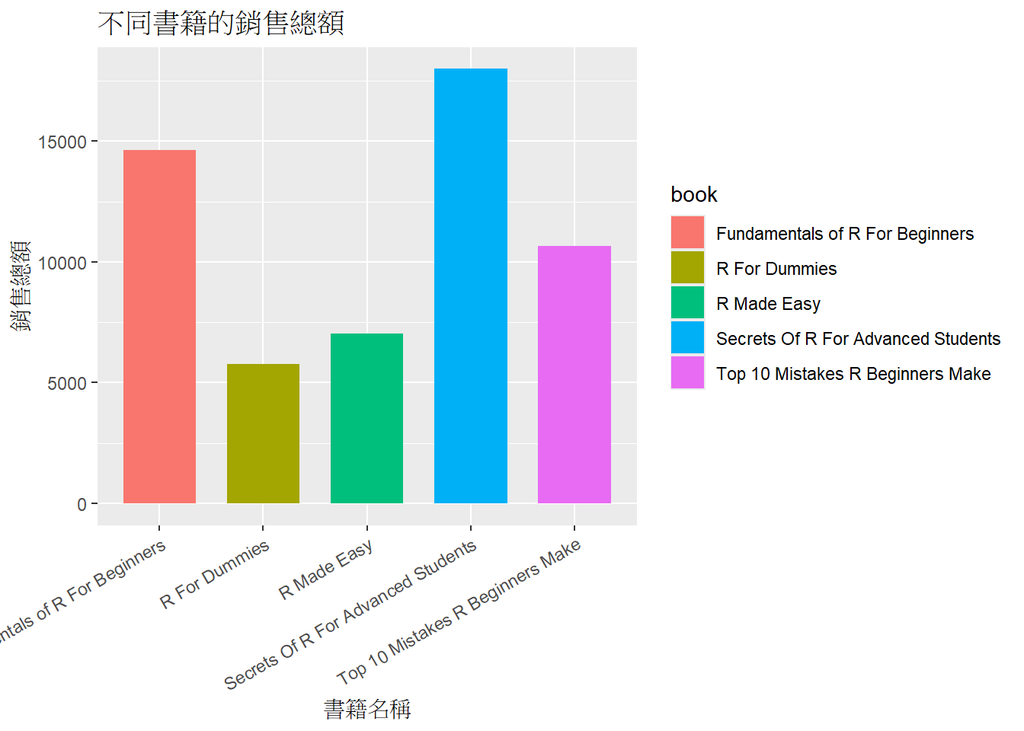

```r
# visualize the analytic result
ggplot(data_1, aes(x = book, y = total, fill = book)) +
  geom_col(width = 0.7) +
  labs(title = "不同書籍的銷售總額", x = "書籍名稱", y = "銷售總額") +
  theme(
    axis.text.x = element_text(angle = 30, hjust = 1) # tilt x-axis labels
  )
```

藉由程式計算，資料集共有五本與R相關書籍的銷售數據，將無評論的數據剔除，結果顯示5本書的銷售量都界在352到366本，所以銷售總額的好壞，就變成幾乎由單價所影響。結果顯示，銷售總額排名為Secrets Of R For Advanced Students, Fundamentals of R For Beginners, Top 10 Mistakes R Beginners Make, R Made Easy, R For Dummies，藉由觀察，除了第一名的客群偏向進階讀者，其他四本書由標題推斷目標客群偏向入門讀者。也就代表說，入門讀者的數量比進階讀者的數量多，並且進階讀者願意用更高的價格購買書籍。

## 分析二

```r
data_2 <- data %>% group_by(state, book) %>% summarise(price = mean(price), count = n(), total = price * count, avg_score = mean(score))
data_2
```

```
## # A tibble: 20 × 6
## # Groups:   state [4]
##    state      book                               price count total avg_score
##    <chr>      <chr>                              <dbl> <int> <dbl>     <dbl>
##  1 California Fundamentals of R For Beginners     40.0    99 3959.      3.02
##  2 California R For Dummies                       16.0   120 1919.      2.72
##  3 California R Made Easy                         20.0    84 1679.      2.95
##  4 California Secrets Of R For Advanced Students  50      84 4200       3.17
##  5 California Top 10 Mistakes R Beginners Make    30.0    77 2309.      3.25
##  6 Florida    Fundamentals of R For Beginners     40.0    74 2959.      2.96
##  7 Florida    R For Dummies                       16.0    77 1231.      3.22
##  8 Florida    R Made Easy                         20.0    85 1699.      3.07
##  9 Florida    Secrets Of R For Advanced Students  50      86 4300       2.94
## 10 Florida    Top 10 Mistakes R Beginners Make    30.0    84 2519.      3.07
## 11 New York   Fundamentals of R For Beginners     40.0    97 3879.      2.97
## 12 New York   R For Dummies                       16.0    81 1295.      2.72
## 13 New York   R Made Easy                         20.0    96 1919.      2.91
## 14 New York   Secrets Of R For Advanced Students  50     108 5400       2.95
## 15 New York   Top 10 Mistakes R Beginners Make    30.0   102 3059.      3.06
## 16 Texas      Fundamentals of R For Beginners     40.0    96 3839.      3.08
## 17 Texas      R For Dummies                       16.0    83 1327.      2.72
## 18 Texas      R Made Easy                         20.0    87 1739.      2.94
## 19 Texas      Secrets Of R For Advanced Students  50      82 4100       2.79
## 20 Texas      Top 10 Mistakes R Beginners Make    30.0    92 2759.      2.85
```

```r
summary(data_2)
```

```
##     state               book               price           count
##  Length:20          Length:20          Min.   :15.99   Min.   : 74.00
##  Class :character   Class :character   1st Qu.:19.99   1st Qu.: 82.75
##  Mode  :character   Mode  :character   Median :29.99   Median : 85.50
##                                        Mean   :31.19   Mean   : 89.70
##                                        3rd Qu.:39.99   3rd Qu.: 96.25
##                                        Max.   :50.00   Max.   :120.00
##      total        avg_score
##  Min.   :1231   Min.   :2.716
##  1st Qu.:1729   1st Qu.:2.892
##  Median :2639   Median :2.957
##  Mean   :2805   Mean   :2.968
##  3rd Qu.:3899   3rd Qu.:3.071
##  Max.   :5400   Max.   :3.247
```

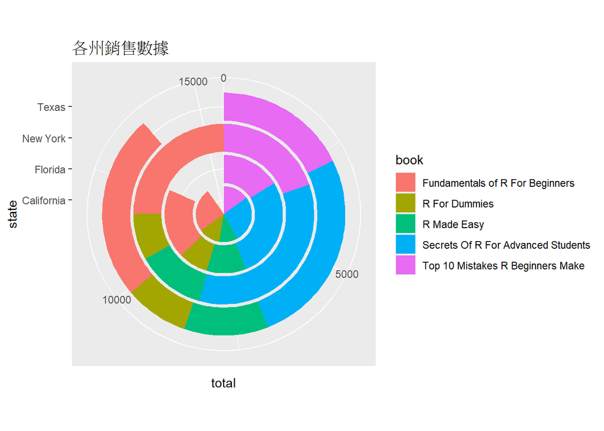

```r
# visualize the analytic result
ggplot(data_2, aes(x = state, y = total, fill = book)) +
  geom_col() +
  coord_polar("y") +  # turn into the pie chart
  labs(title = "各州銷售數據")
```

藉由觀察，我們可以得知：  
銷售總額：紐約 > 加州 > 德州 > 佛羅里達，以及各州最熱銷(書本數量/銷售總額)的書分別是：  
紐約：Secrets Of R For Advanced Students/Secrets Of R For Advanced Students  
加州：R For Dummies/Secrets Of R For Advanced Students  
德州：Fundamentals of R For Beginners/Secrets Of R For Advanced Students  
佛羅里達：Secrets Of R For Advanced Students/Secrets Of R For Advanced Students